# 零基础入门数据挖掘 - 二手车交易价格预测

https://tianchi.aliyun.com/competition/entrance/231784/score

```python
# 导入相关模块
import pandas as pd
import statsmodels.api as sm
import matplotlib.pyplot as plt
import seaborn as sns
import statsmodels.formula.api as smf
from statsmodels.stats.anova import anova_lm
from sklearn.model_selection import train_test_split
from sklearn.metrics import mean_absolute_error
from sklearn.ensemble import RandomForestRegressor
plt.rcParams['font.sans-serif'] = ['SimHei']
plt.rcParams['axes.unicode_minus'] = False
```

## 查看数据

```python
# 导入数据
df = pd.read_csv('data/used_car_train_20200313.csv',sep=' ',low_memory=True)
# 删除没有用的列 -- 无研究意义的类别变量
del df['name'],df['model'],df['regionCode']
# 查看数据
df
```

|  | SaleID | regDate | brand | bodyType | fuelType | gearbox | power | kilometer | notRepairedDamage | seller | ... | v_5 | v_6 | v_7 | v_8 | v_9 | v_10 | v_11 | v_12 | v_13 | v_14 |
| --- | --- | --- | --- | --- | --- | --- | --- | --- | --- | --- | --- | --- | --- | --- | --- | --- | --- | --- | --- | --- | --- |
| 0 | 0 | 20040402 | 6 | 1.0 | 0.0 | 0.0 | 60 | 12.5 | 0.0 | 0 | ... | 0.235676 | 0.101988 | 0.129549 | 0.022816 | 0.097462 | -2.881803 | 2.804097 | -2.420821 | 0.795292 | 0.914762 |
| 1 | 1 | 20030301 | 1 | 2.0 | 0.0 | 0.0 | 0 | 15.0 | - | 0 | ... | 0.264777 | 0.121004 | 0.135731 | 0.026597 | 0.020582 | -4.900482 | 2.096338 | -1.030483 | -1.722674 | 0.245522 |
| 2 | 2 | 20040403 | 15 | 1.0 | 0.0 | 0.0 | 163 | 12.5 | 0.0 | 0 | ... | 0.251410 | 0.114912 | 0.165147 | 0.062173 | 0.027075 | -4.846749 | 1.803559 | 1.565330 | -0.832687 | -0.229963 |
| 3 | 3 | 19960908 | 10 | 0.0 | 0.0 | 1.0 | 193 | 15.0 | 0.0 | 0 | ... | 0.274293 | 0.110300 | 0.121964 | 0.033395 | 0.000000 | -4.509599 | 1.285940 | -0.501868 | -2.438353 | -0.478699 |
| 4 | 4 | 20120103 | 5 | 1.0 | 0.0 | 0.0 | 68 | 5.0 | 0.0 | 0 | ... | 0.228036 | 0.073205 | 0.091880 | 0.078819 | 0.121534 | -1.896240 | 0.910783 | 0.931110 | 2.834518 | 1.923482 |
| ... | ... | ... | ... | ... | ... | ... | ... | ... | ... | ... | ... | ... | ... | ... | ... | ... | ... | ... | ... | ... | ... |
| 149995 | 149995 | 20000607 | 10 | 4.0 | 0.0 | 1.0 | 163 | 15.0 | 0.0 | 0 | ... | 0.280264 | 0.000310 | 0.048441 | 0.071158 | 0.019174 | 1.988114 | -2.983973 | 0.589167 | -1.304370 | -0.302592 |
| 149996 | 149996 | 20091102 | 11 | 0.0 | 0.0 | 0.0 | 125 | 10.0 | 0.0 | 0 | ... | 0.253217 | 0.000777 | 0.084079 | 0.099681 | 0.079371 | 1.839166 | -2.774615 | 2.553994 | 0.924196 | -0.272160 |
| 149997 | 149997 | 20101003 | 11 | 1.0 | 1.0 | 0.0 | 90 | 6.0 | 0.0 | 0 | ... | 0.233353 | 0.000705 | 0.118872 | 0.100118 | 0.097914 | 2.439812 | -1.630677 | 2.290197 | 1.891922 | 0.414931 |
| 149998 | 149998 | 20060312 | 10 | 3.0 | 1.0 | 0.0 | 156 | 15.0 | 0.0 | 0 | ... | 0.256369 | 0.000252 | 0.081479 | 0.083558 | 0.081498 | 2.075380 | -2.633719 | 1.414937 | 0.431981 | -1.659014 |
| 149999 | 149999 | 19990204 | 28 | 6.0 | 0.0 | 1.0 | 193 | 12.5 | 0.0 | 0 | ... | 0.284475 | 0.000000 | 0.040072 | 0.062543 | 0.025819 | 1.978453 | -3.179913 | 0.031724 | -1.483350 | -0.342674 |

150000 rows × 28 columns

```python
# 查看数据类型与空值情况
df.info()
```

```
<class 'pandas.core.frame.DataFrame'>
RangeIndex: 150000 entries, 0 to 149999
Data columns (total 28 columns):
SaleID               150000 non-null int64
regDate              150000 non-null int64
brand                150000 non-null int64
bodyType             145494 non-null float64
fuelType             141320 non-null float64
gearbox              144019 non-null float64
power                150000 non-null int64
kilometer            150000 non-null float64
notRepairedDamage    150000 non-null object
seller               150000 non-null int64
offerType            150000 non-null int64
creatDate            150000 non-null int64
price                150000 non-null int64
v_0                  150000 non-null float64
v_1                  150000 non-null float64
v_2                  150000 non-null float64
v_3                  150000 non-null float64
v_4                  150000 non-null float64
v_5                  150000 non-null float64
v_6                  150000 non-null float64
v_7                  150000 non-null float64
v_8                  150000 non-null float64
v_9                  150000 non-null float64
v_10                 150000 non-null float64
v_11                 150000 non-null float64
v_12                 150000 non-null float64
v_13                 150000 non-null float64
v_14                 150000 non-null float64
dtypes: float64(19), int64(8), object(1)
memory usage: 32.0+ MB
```

## 数据清洗

### 去除空值，修改异常值，调整变量类型，确保真实类别变量、数值变量和时序变量

```python
# 观察到含空值的行占总体约21.1%，仍在可接受范围，可予以去除
df = df.replace('-',pd.np.nan)
df = df.dropna()
len(df)
```

```
118327
```

```python
# 类别变量
for col in ['brand','bodyType','fuelType','gearbox','notRepairedDamage','seller', 'offerType']:
    print(col)
    df[col] = df[col].apply(lambda x:str(int(x)) if isinstance(x,int) or isinstance(x,float) else str(int(eval(x))))
```

```
brand
bodyType
fuelType
gearbox
notRepairedDamage
seller
offerType
```

```python
# 时序变量
for col in ['regDate','creatDate']:
    df[col] = pd.to_datetime(df[col],format='%Y%m%d', errors='coerce')
df['wait_time'] = (df['creatDate']-df['regDate']).dt.days
now = pd.datetime.now()
df['create_date_passed'] = (now-df['creatDate']).dt.days
df['reg_date_passed'] = (now-df['regDate']).dt.days
del df['regDate'],df['creatDate']
# 相对最初，空值数据较少
df = df.dropna()
```

```python
# 数值变量，检查数值变量是否在合适的区间
df.describe()
```

|  | SaleID | power | kilometer | price | v_0 | v_1 | v_2 | v_3 | v_4 | v_5 | ... | v_8 | v_9 | v_10 | v_11 | v_12 | v_13 | v_14 | wait_time | create_date_passed | reg_date_passed |
| --- | --- | --- | --- | --- | --- | --- | --- | --- | --- | --- | --- | --- | --- | --- | --- | --- | --- | --- | --- | --- | --- |
| count | 114992.000000 | 114992.000000 | 114992.000000 | 114992.000000 | 114992.000000 | 114992.000000 | 114992.000000 | 114992.000000 | 114992.000000 | 114992.000000 | ... | 114992.000000 | 114992.000000 | 114992.000000 | 114992.000000 | 114992.000000 | 114992.000000 | 114992.000000 | 114992.000000 | 114992.000000 | 114992.000000 |
| mean | 75044.209128 | 127.907881 | 12.395919 | 6737.086545 | 44.927435 | 0.420177 | -0.314378 | -0.232663 | 0.021919 | 0.256301 | ... | 0.060547 | 0.062793 | -0.736039 | -0.420218 | 0.119658 | 0.057336 | 0.013125 | 4292.911333 | 1544.132427 | 5837.043760 |
| std | 43330.128216 | 144.090476 | 3.968514 | 7945.276733 | 1.883407 | 3.701538 | 0.829003 | 1.922156 | 1.203121 | 0.014024 | ... | 0.028809 | 0.035459 | 3.486493 | 1.902584 | 2.293009 | 1.293900 | 1.076392 | 1958.375311 | 9.400430 | 1958.374964 |
| min | 0.000000 | 0.000000 | 0.500000 | 13.000000 | 37.109149 | -3.555951 | -4.470671 | -7.275037 | -4.364565 | 0.181562 | ... | 0.000000 | 0.000000 | -9.168192 | -5.558207 | -9.639552 | -4.074922 | -6.546556 | 88.000000 | 1527.000000 | 1644.000000 |
| 25% | 37469.750000 | 80.000000 | 10.000000 | 1650.000000 | 43.595295 | -3.171500 | -0.886675 | -1.707827 | -0.921974 | 0.245909 | ... | 0.037693 | 0.034608 | -4.099940 | -2.028842 | -1.633676 | -0.998320 | -0.425483 | 2792.000000 | 1536.000000 | 4330.000000 |
| 50% | 75030.500000 | 116.000000 | 15.000000 | 3999.000000 | 44.967617 | -2.940422 | -0.304659 | -0.263603 | -0.076760 | 0.258916 | ... | 0.059837 | 0.059236 | 0.753134 | -0.274692 | 0.070645 | 0.023365 | 0.168972 | 4257.000000 | 1544.000000 | 5794.000000 |
| 75% | 112597.250000 | 156.000000 | 15.000000 | 8900.000000 | 46.282668 | 4.205891 | 0.277911 | 1.250221 | 0.880747 | 0.265742 | ... | 0.081695 | 0.088031 | 2.505696 | 1.209867 | 1.854992 | 1.003305 | 0.730390 | 5804.000000 | 1552.000000 | 7344.000000 |
| max | 149999.000000 | 17700.000000 | 15.000000 | 99999.000000 | 52.304178 | 7.320308 | 2.626632 | 8.065651 | 6.829352 | 0.291838 | ... | 0.151107 | 0.222787 | 5.831949 | 3.710056 | 7.800208 | 11.147669 | 8.658418 | 9222.000000 | 1771.000000 | 10755.000000 |

8 rows × 22 columns

经检查，均满足要求

## 描述性统计分析

```python
# 将SaleID作为索引
df = df.set_index('SaleID')
```

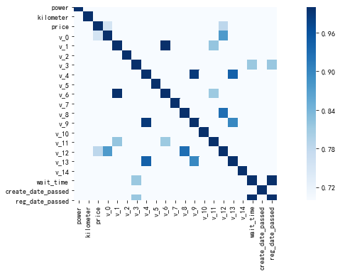

```python
# 查看各变量间的强正相关系数
plt.figure(figsize=(15,5))
sns.heatmap(df.corr(),square=True,cmap="Blues",vmax=1,vmin=0.7)
```

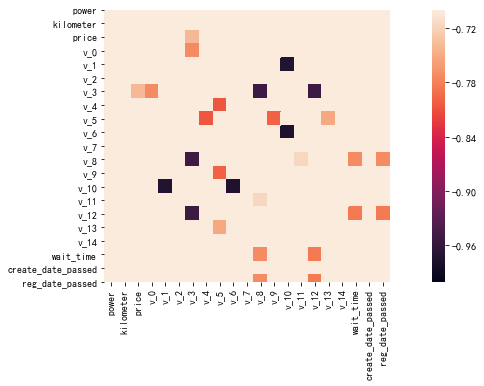

```python
# 查看各变量间的强负相关系数
plt.figure(figsize=(15,5))
sns.heatmap(df.corr(),square=True,vmax=-.7,vmin=-1)
```

price与v_0和v12有强正相关，与v_3有强负相关

```python
# 获得数值型变量和分类型变量
col_num = [col for col in df if df[col].dtype != object]
col_obj = [col for col in df if df[col].dtype == object]
len(col_num),len(col_obj)
```

```
(21, 7)
```

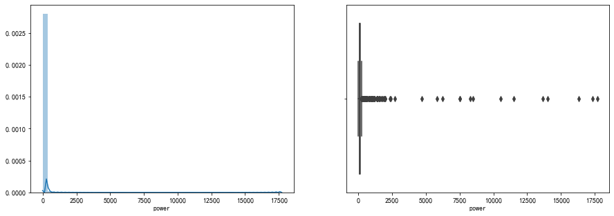

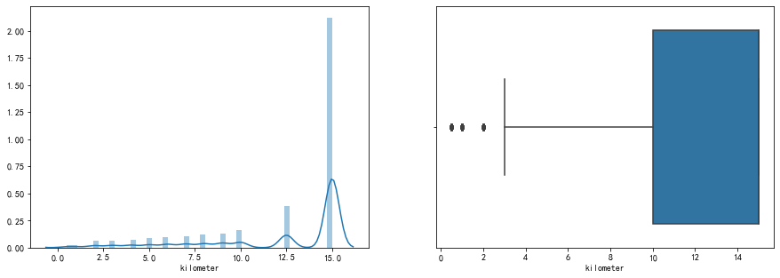

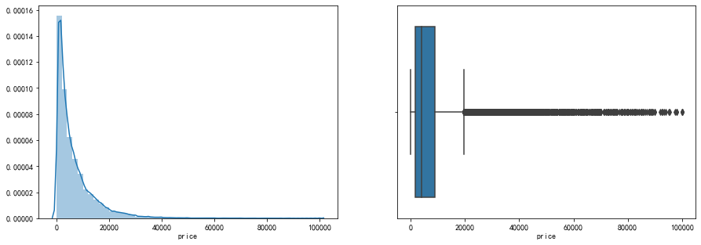

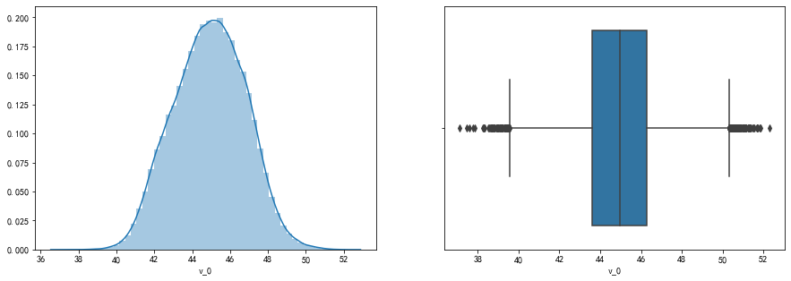

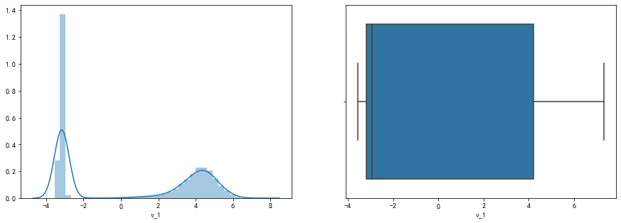

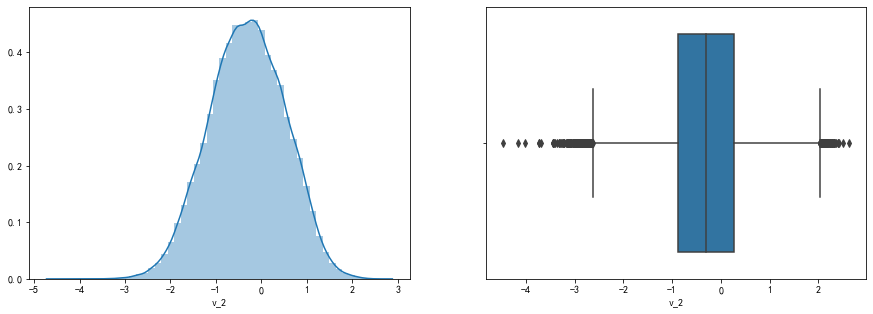

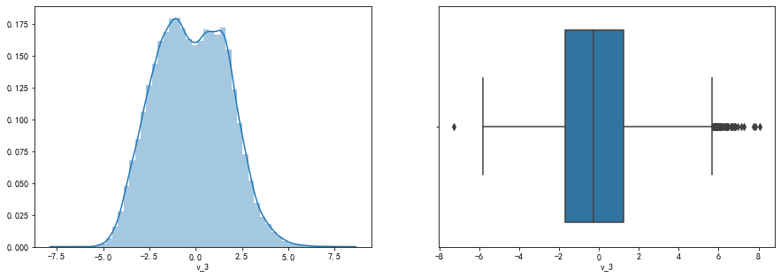

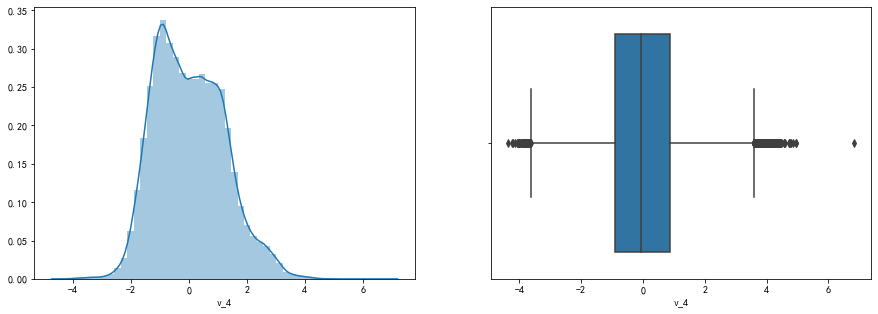

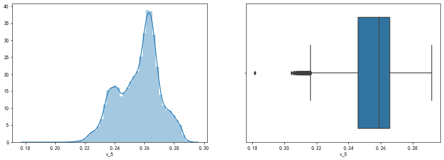

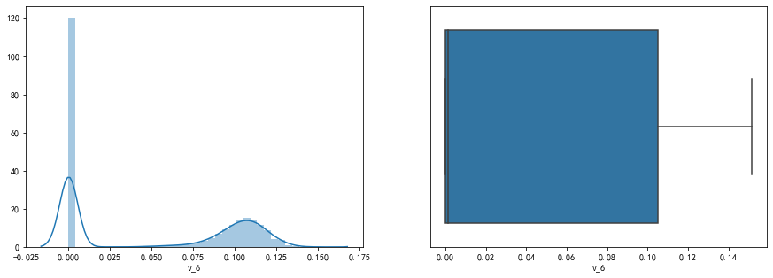

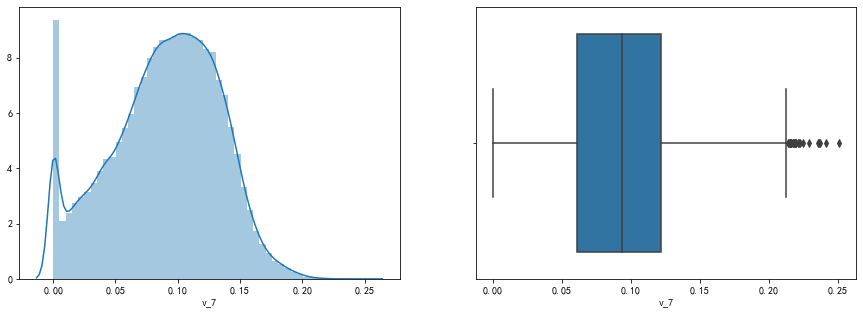

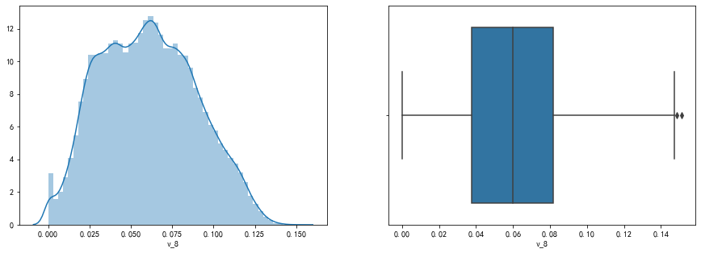

[9 more figures not shown]

```python
# 查看数值型变量的分布
for index,col in enumerate(col_num):
    plt.figure(figsize=(15,5))
    plt.subplot(1,2,1)
    sns.distplot(df[col])
    plt.subplot(1,2,2)
    sns.boxplot(df[col])
    plt.show()
```

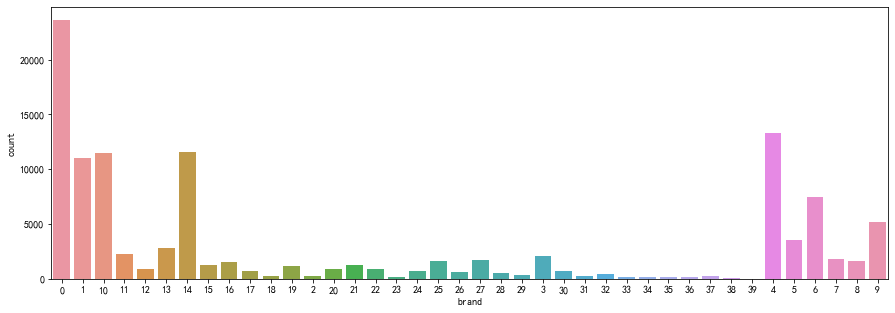

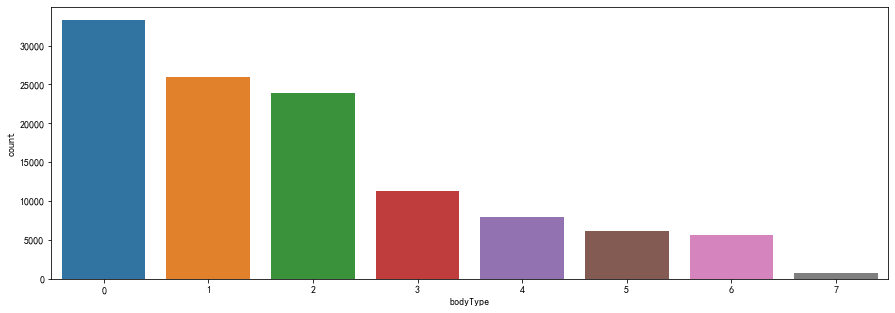

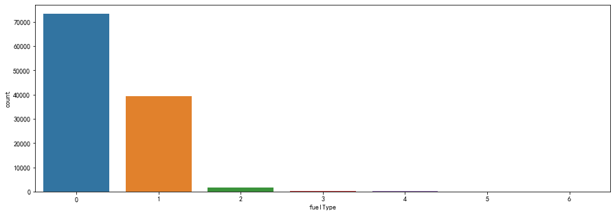

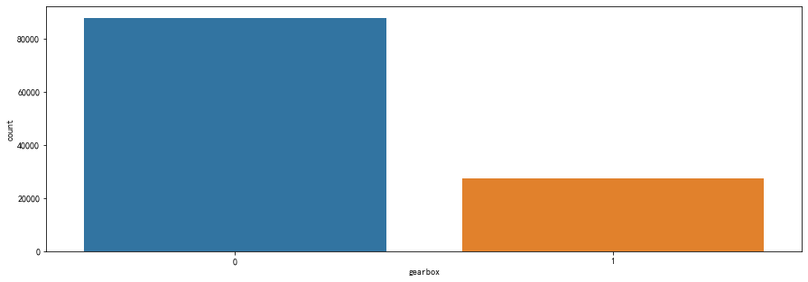

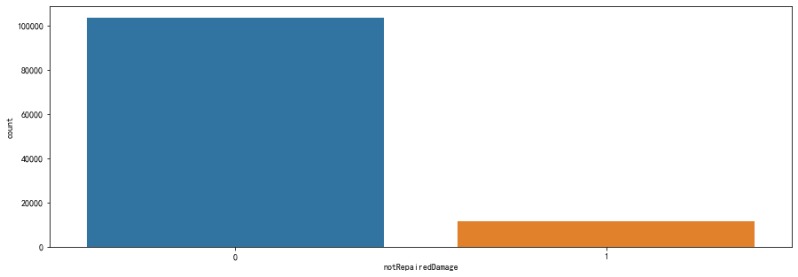

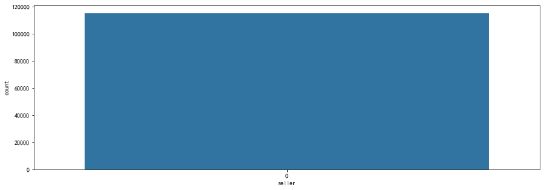

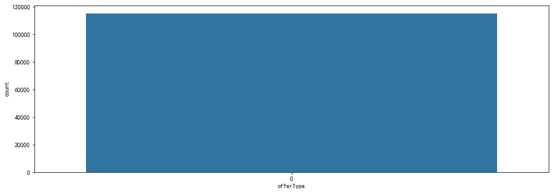

```python
# 查看类别变量的分布
for col in col_obj:
    plt.figure(figsize=(15,5))
    sns.countplot(x=col, data=df);
    plt.show()
```

由上图可以看出，

1. brand取0，4，1，10，14较多，39最少
2. bodyType取0，1，2较多，7最少
3. fuelType取0最多，5和6最少
4. gear取0最多，取1最少
5. notRepairedDamage取0最多，取1最少
6. seller和offerType只取一个值

```
brand
```

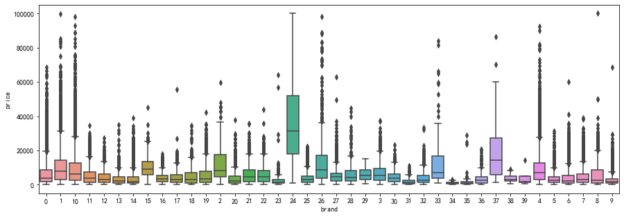

```
                df        sum_sq       mean_sq           F  PR(>F)
C(brand)      39.0  1.440198e+12  3.692816e+10  729.515053     0.0
Residual  114952.0  5.818887e+12  5.062015e+07         NaN     NaN
bodyType
```

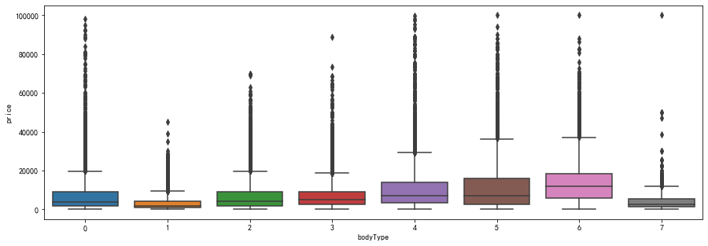

```
                   df        sum_sq       mean_sq            F  PR(>F)
C(bodyType)       7.0  8.702843e+11  1.243263e+11  2237.593296     0.0
Residual     114984.0  6.388801e+12  5.556252e+07          NaN     NaN
fuelType
```

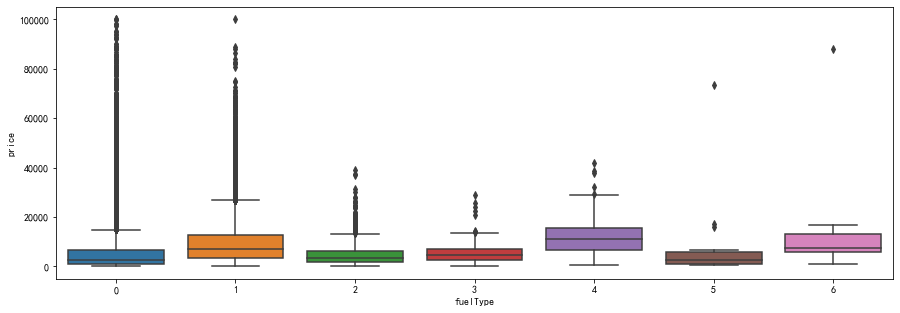

```
                   df        sum_sq       mean_sq            F  PR(>F)
C(fuelType)       6.0  4.163205e+11  6.938676e+10  1165.966743     0.0
Residual     114985.0  6.842765e+12  5.951007e+07          NaN     NaN
gearbox
```

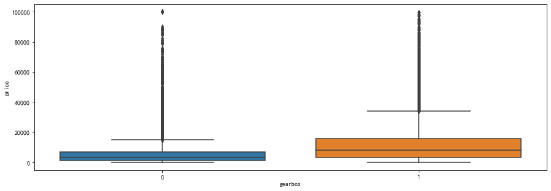

```
                  df        sum_sq       mean_sq             F  PR(>F)
C(gearbox)       1.0  7.978727e+11  7.978727e+11  14199.715758     0.0
Residual    114990.0  6.461213e+12  5.618934e+07           NaN     NaN
notRepairedDamage
```

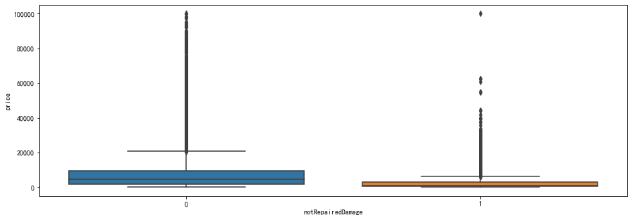

```
                            df        sum_sq       mean_sq           F  PR(>F)
C(notRepairedDamage)       1.0  2.283414e+11  2.283414e+11  3734.59484     0.0
Residual              114990.0  7.030744e+12  6.114222e+07         NaN     NaN
seller
```

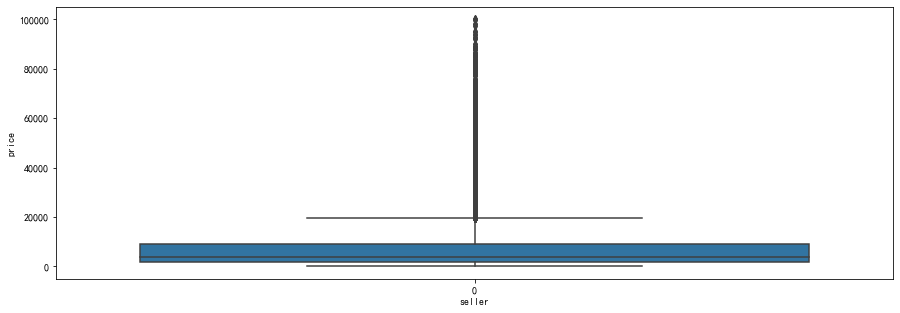

```
                 df        sum_sq       mean_sq   F  PR(>F)
C(seller)       0.0  0.000000e+00           NaN NaN     NaN
Residual   114991.0  7.259085e+12  6.312742e+07 NaN     NaN
offerType
```

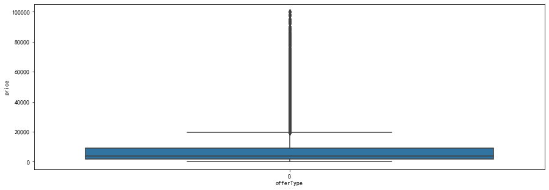

```
                    df        sum_sq       mean_sq   F  PR(>F)
C(offerType)       0.0  0.000000e+00           NaN NaN     NaN
Residual      114991.0  7.259085e+12  6.312742e+07 NaN     NaN
```

```python
# 观察类别变量对price的影响
for col in col_obj:
    print(col)
    plt.figure(figsize=(15,5))
    sns.boxplot(x=col, y="price", data=df)
    plt.show()
    anova = anova_lm(smf.ols('price ~ C(%s)' % col, data=df).fit())
    print(anova)
```

除了seller和offerType只有一个变量，其他的p值均小于0.05，即拒绝原假设，表明各分类变量对price影响显著

## 模型分析

### 二次数据清洗

```python
del df['seller']
del df['offerType']
# 添加哑变量，并去除原来的分类变量
for col in ['brand','bodyType','fuelType','gearbox','notRepairedDamage']:
    print(col,set(df[col]))
    df = df.join(pd.get_dummies(df[col],prefix=col))
    del df[col]
# 分割x,y
x_cols = df.columns.tolist()
x_cols.remove('price')
```

```
brand {'19', '33', '30', '38', '9', '17', '16', '37', '32', '22', '4', '14', '20', '25', '3', '10', '2', '7', '27', '35', '0', '6', '1', '39', '11', '26', '36', '31', '15', '12', '29', '24', '8', '18', '5', '28', '21', '23', '34', '13'}
bodyType {'0', '1', '6', '3', '2', '7', '4', '5'}
fuelType {'0', '1', '6', '3', '2', '4', '5'}
gearbox {'0', '1'}
notRepairedDamage {'0', '1'}
```

### 多元回归分析

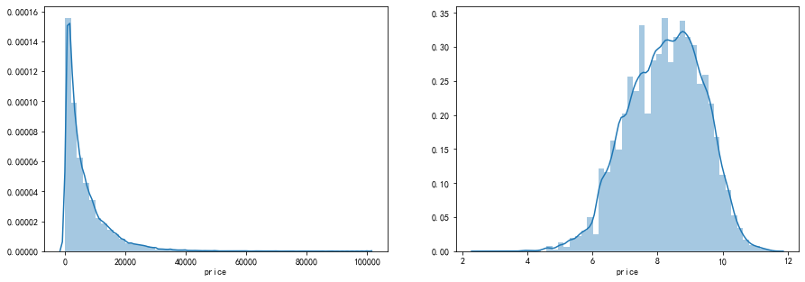

```python
# 查看函数值分布
plt.figure(figsize=(15,5))
plt.subplot(1,2,1)
sns.distplot(df['price'])
plt.subplot(1,2,2)
sns.distplot(pd.np.log(df['price']+1))
```

```python
# 最小二乘法
## 调整y
df['price_log'] = pd.np.log(df['price']+1)
t = smf.ols("{}~{}".format('price_log', '+'.join(x_cols)),df).fit()
t.summary()
```

OLS Regression Results

| Dep. Variable: | price_log | R-squared: | 0.935 |
| --- | --- | --- | --- |
| Model: | OLS | Adj. R-squared: | 0.935 |
| Method: | Least Squares | F-statistic: | 2.251e+04 |
| Date: | Fri, 12 Jun 2020 | Prob (F-statistic): | 0.00 |
| Time: | 18:46:28 | Log-Likelihood: | -21853. |
| No. Observations: | 114992 | AIC: | 4.385e+04 |
| Df Residuals: | 114918 | BIC: | 4.457e+04 |
| Df Model: | 73 |  |  |
| Covariance Type: | nonrobust |  |  |

|  | coef | std err | t | P>\|t\| | [0.025 | 0.975] |
| --- | --- | --- | --- | --- | --- | --- |
| Intercept | -1.446e+06 | 1e+05 | -14.441 | 0.000 | -1.64e+06 | -1.25e+06 |
| power | 0.0001 | 6.4e-06 | 17.438 | 0.000 | 9.9e-05 | 0.000 |
| kilometer | -0.0117 | 0.000 | -40.269 | 0.000 | -0.012 | -0.011 |
| v_0 | 7.564e+04 | 5239.247 | 14.438 | 0.000 | 6.54e+04 | 8.59e+04 |
| v_1 | 1.862e+06 | 1.27e+05 | 14.649 | 0.000 | 1.61e+06 | 2.11e+06 |
| v_2 | 7.014e+05 | 4.75e+04 | 14.769 | 0.000 | 6.08e+05 | 7.94e+05 |
| v_3 | -4.055e+04 | 2682.116 | -15.120 | 0.000 | -4.58e+04 | -3.53e+04 |
| v_4 | 564.3251 | 34.364 | 16.422 | 0.000 | 496.971 | 631.679 |
| v_5 | 1010.1719 | 295.421 | 3.419 | 0.001 | 431.152 | 1589.192 |
| v_6 | -79.1549 | 20.613 | -3.840 | 0.000 | -119.556 | -38.754 |
| v_7 | 175.2084 | 51.148 | 3.426 | 0.001 | 74.959 | 275.458 |
| v_8 | 236.5253 | 78.406 | 3.017 | 0.003 | 82.851 | 390.199 |
| v_9 | 262.0606 | 74.127 | 3.535 | 0.000 | 116.773 | 407.348 |
| v_10 | 1.549e+06 | 1.06e+05 | 14.636 | 0.000 | 1.34e+06 | 1.76e+06 |
| v_11 | -1.227e+06 | 8.35e+04 | -14.700 | 0.000 | -1.39e+06 | -1.06e+06 |
| v_12 | -2.503e+05 | 1.68e+04 | -14.879 | 0.000 | -2.83e+05 | -2.17e+05 |
| v_13 | -1287.9570 | 79.897 | -16.120 | 0.000 | -1444.554 | -1131.360 |
| v_14 | 16.4417 | 0.971 | 16.941 | 0.000 | 14.539 | 18.344 |
| wait_time | 6.6494 | 0.456 | 14.579 | 0.000 | 5.755 | 7.543 |
| create_date_passed | 6.6486 | 0.456 | 14.577 | 0.000 | 5.755 | 7.543 |
| reg_date_passed | -6.6494 | 0.456 | -14.579 | 0.000 | -7.543 | -5.755 |
| brand_0 | -3.615e+04 | 2503.321 | -14.441 | 0.000 | -4.11e+04 | -3.12e+04 |
| brand_1 | -3.615e+04 | 2503.326 | -14.441 | 0.000 | -4.11e+04 | -3.12e+04 |
| brand_10 | -3.615e+04 | 2503.325 | -14.441 | 0.000 | -4.11e+04 | -3.12e+04 |
| brand_11 | -3.615e+04 | 2503.316 | -14.441 | 0.000 | -4.11e+04 | -3.12e+04 |
| brand_12 | -3.615e+04 | 2503.316 | -14.441 | 0.000 | -4.11e+04 | -3.12e+04 |
| brand_13 | -3.615e+04 | 2503.312 | -14.441 | 0.000 | -4.11e+04 | -3.12e+04 |
| brand_14 | -3.615e+04 | 2503.314 | -14.441 | 0.000 | -4.11e+04 | -3.12e+04 |
| brand_15 | -3.615e+04 | 2503.325 | -14.441 | 0.000 | -4.11e+04 | -3.12e+04 |
| brand_16 | -3.615e+04 | 2503.316 | -14.441 | 0.000 | -4.11e+04 | -3.12e+04 |
| brand_17 | -3.615e+04 | 2503.316 | -14.441 | 0.000 | -4.11e+04 | -3.12e+04 |
| brand_18 | -3.615e+04 | 2503.315 | -14.441 | 0.000 | -4.11e+04 | -3.12e+04 |
| brand_19 | -3.615e+04 | 2503.319 | -14.441 | 0.000 | -4.11e+04 | -3.12e+04 |
| brand_2 | -3.615e+04 | 2503.325 | -14.441 | 0.000 | -4.11e+04 | -3.12e+04 |
| brand_20 | -3.615e+04 | 2503.315 | -14.441 | 0.000 | -4.11e+04 | -3.12e+04 |
| brand_21 | -3.615e+04 | 2503.320 | -14.441 | 0.000 | -4.11e+04 | -3.12e+04 |
| brand_22 | -3.615e+04 | 2503.319 | -14.441 | 0.000 | -4.11e+04 | -3.12e+04 |
| brand_23 | -3.615e+04 | 2503.313 | -14.441 | 0.000 | -4.11e+04 | -3.12e+04 |
| brand_24 | -3.615e+04 | 2503.338 | -14.441 | 0.000 | -4.11e+04 | -3.12e+04 |
| brand_25 | -3.615e+04 | 2503.315 | -14.441 | 0.000 | -4.11e+04 | -3.12e+04 |
| brand_26 | -3.615e+04 | 2503.327 | -14.441 | 0.000 | -4.11e+04 | -3.12e+04 |
| brand_27 | -3.615e+04 | 2503.319 | -14.441 | 0.000 | -4.11e+04 | -3.12e+04 |
| brand_28 | -3.615e+04 | 2503.319 | -14.441 | 0.000 | -4.11e+04 | -3.12e+04 |
| brand_29 | -3.615e+04 | 2503.318 | -14.441 | 0.000 | -4.11e+04 | -3.12e+04 |
| brand_3 | -3.615e+04 | 2503.321 | -14.441 | 0.000 | -4.11e+04 | -3.12e+04 |
| brand_30 | -3.615e+04 | 2503.314 | -14.441 | 0.000 | -4.11e+04 | -3.12e+04 |
| brand_31 | -3.615e+04 | 2503.306 | -14.441 | 0.000 | -4.11e+04 | -3.12e+04 |
| brand_32 | -3.615e+04 | 2503.314 | -14.441 | 0.000 | -4.11e+04 | -3.12e+04 |
| brand_33 | -3.615e+04 | 2503.324 | -14.441 | 0.000 | -4.11e+04 | -3.12e+04 |
| brand_34 | -3.615e+04 | 2503.294 | -14.441 | 0.000 | -4.11e+04 | -3.12e+04 |
| brand_35 | -3.615e+04 | 2503.307 | -14.441 | 0.000 | -4.11e+04 | -3.12e+04 |
| brand_36 | -3.615e+04 | 2503.312 | -14.441 | 0.000 | -4.11e+04 | -3.12e+04 |
| brand_37 | -3.615e+04 | 2503.326 | -14.441 | 0.000 | -4.11e+04 | -3.12e+04 |
| brand_38 | -3.615e+04 | 2503.306 | -14.441 | 0.000 | -4.11e+04 | -3.12e+04 |
| brand_39 | -3.615e+04 | 2503.310 | -14.441 | 0.000 | -4.11e+04 | -3.12e+04 |
| brand_4 | -3.615e+04 | 2503.326 | -14.441 | 0.000 | -4.11e+04 | -3.12e+04 |
| brand_5 | -3.615e+04 | 2503.315 | -14.441 | 0.000 | -4.11e+04 | -3.12e+04 |
| brand_6 | -3.615e+04 | 2503.317 | -14.441 | 0.000 | -4.11e+04 | -3.12e+04 |
| brand_7 | -3.615e+04 | 2503.315 | -14.441 | 0.000 | -4.11e+04 | -3.12e+04 |
| brand_8 | -3.615e+04 | 2503.318 | -14.441 | 0.000 | -4.11e+04 | -3.12e+04 |
| brand_9 | -3.615e+04 | 2503.312 | -14.441 | 0.000 | -4.11e+04 | -3.12e+04 |
| bodyType_0 | -1.807e+05 | 1.25e+04 | -14.441 | 0.000 | -2.05e+05 | -1.56e+05 |
| bodyType_1 | -1.807e+05 | 1.25e+04 | -14.441 | 0.000 | -2.05e+05 | -1.56e+05 |
| bodyType_2 | -1.807e+05 | 1.25e+04 | -14.441 | 0.000 | -2.05e+05 | -1.56e+05 |
| bodyType_3 | -1.808e+05 | 1.25e+04 | -14.441 | 0.000 | -2.05e+05 | -1.56e+05 |
| bodyType_4 | -1.808e+05 | 1.25e+04 | -14.441 | 0.000 | -2.05e+05 | -1.56e+05 |
| bodyType_5 | -1.808e+05 | 1.25e+04 | -14.441 | 0.000 | -2.05e+05 | -1.56e+05 |
| bodyType_6 | -1.808e+05 | 1.25e+04 | -14.441 | 0.000 | -2.05e+05 | -1.56e+05 |
| bodyType_7 | -1.807e+05 | 1.25e+04 | -14.441 | 0.000 | -2.05e+05 | -1.56e+05 |
| fuelType_0 | -2.066e+05 | 1.43e+04 | -14.441 | 0.000 | -2.35e+05 | -1.79e+05 |
| fuelType_1 | -2.066e+05 | 1.43e+04 | -14.441 | 0.000 | -2.35e+05 | -1.79e+05 |
| fuelType_2 | -2.066e+05 | 1.43e+04 | -14.441 | 0.000 | -2.35e+05 | -1.79e+05 |
| fuelType_3 | -2.066e+05 | 1.43e+04 | -14.441 | 0.000 | -2.35e+05 | -1.79e+05 |
| fuelType_4 | -2.066e+05 | 1.43e+04 | -14.441 | 0.000 | -2.35e+05 | -1.79e+05 |
| fuelType_5 | -2.066e+05 | 1.43e+04 | -14.441 | 0.000 | -2.35e+05 | -1.79e+05 |
| fuelType_6 | -2.066e+05 | 1.43e+04 | -14.441 | 0.000 | -2.35e+05 | -1.79e+05 |
| gearbox_0 | -7.23e+05 | 5.01e+04 | -14.441 | 0.000 | -8.21e+05 | -6.25e+05 |
| gearbox_1 | -7.23e+05 | 5.01e+04 | -14.441 | 0.000 | -8.21e+05 | -6.25e+05 |
| notRepairedDamage_0 | -7.23e+05 | 5.01e+04 | -14.441 | 0.000 | -8.21e+05 | -6.25e+05 |
| notRepairedDamage_1 | -7.23e+05 | 5.01e+04 | -14.441 | 0.000 | -8.21e+05 | -6.25e+05 |

| Omnibus: | 21128.462 | Durbin-Watson: | 2.001 |
| --- | --- | --- | --- |
| Prob(Omnibus): | 0.000 | Jarque-Bera (JB): | 229983.358 |
| Skew: | -0.566 | Prob(JB): | 0.00 |
| Kurtosis: | 9.835 | Cond. No. | 1.06e+16 |

Warnings:  
[1] Standard Errors assume that the covariance matrix of the errors is correctly specified.  
[2] The smallest eigenvalue is 6.3e-20. This might indicate that there are  
strong multicollinearity problems or that the design matrix is singular.

由上表可知，因变量为price对数变换后时，其模型显著(小于0.05)，且各自变量均显著(均小于0.05)且能够很好地解释因变量，残差项间无相关(DW接近2,2.001)，R-squared和Adj.R-squared 均为0.935,表明模型具有较强的解释能力